# Tornados are most harmfull to public health, floods - to economics.

Gleb Artamonov

2018 july

## Synopsis

The report shows that tornados are most harmfull to public health, and floods are most harmfull to property/crop damage. The calculations are made on modified event variable. Event type variable was modified to addreses next problems: multiple word forms, presence of irrelevant (for summary purposes) information within event (measurments, magnitudes, names). Report addresses only most impactfull weather events that together are responsible for at least 80% of given(public health, property) damage done. Anything that in last 20% of damage done is summarized in ‘other’ event and stands for multiple-event cases, cases with bad labeling and least damaging events.

## Data processing

### Reading the data

```r
library(data.table,quietly = T)
library(magrittr)
library(ggplot2)
library(knitr)
options(scipen = 100)
options(stringsAsFactors = T)
#reading and setting as data.table
storm = read.csv("./repdata%2Fdata%2FStormData.csv") %>% setDT
#set names to lower case
names(storm) %<>% tolower()
```

```r
#summary - not gonna print it in output
summary(storm)
```

Lets look how events are labeled and how many unique events are in data.

```r
events_number=storm$evtype %>% unique %>% length()
events_number
```

```
## [1] 985
```

There is a lot of unique event labels (985)! And it is actually pretty dirty variable. Some summary may be seen with next 2 commands(not printed dew to big size):

```r
#number of cases per label sorted in alphabetical order
storm$evtype %>% table
#same but sorted from most to least common
storm$evtype %>% table %>% sort
```

### Event type cleaning

Event-type variable has number of problems. Lets name a few:

- some events are misspelled or have range of word-forms or abbreviations
- some events have different punctuation marks(/,-.)
- some cases are periodic summaries and have nothing to do with event types
- some cases have intensity measures within label(speed, sizes etc.) or quality magnitudes (extreme/record etc.)

We’ll do several steps to address mentioned problems. Before any transoformations we will exclude from analysis all cases that have “summary” in event variable for obvious reasons. First, we’ll get rid of any symbols that are not number or charecter and transform all events to lower case. Then we’ll delete adjectives like record/excessive/extreme so “record heat” will become just a “heat”. Also we’ll substitute longer forms of words with shorter ones (flooding->flood,winds->wind etc.) Thundestorms in lables will be substituted to tstm. Hails of different sizes are summarized to hail, speed measures are removed also. After that named hurricanes summarized to hurricane. Also any extra spaces in labeles are trimmed.

```r
#all events to lower case
storm$evtype %<>% as.character() %>% tolower()
storm[,evtype_short:=evtype]
#get rid off summary rows
storm2=storm[!grepl("summary",evtype)]
#chain of gsub cleaning of event types
storm2$evtype_short = storm2$evtype %>% gsub("[^[:alnum:].]"," ",.) %>%
      trimws %>% gsub("\\s+"," ",.) %>% gsub("\\.$","",.) %>%
      gsub("winds","wind",.) %>% gsub("record|excessive|extreme|dense","",.) %>%
      gsub("thunderstorms?","tstm",.) %>% gsub("flooding","flood",.) %>%
      gsub("rain","rains",.) %>%
      gsub("hail[ .0-9]+$","hail",.) %>%  gsub("\\s?g?\\d+\\s?(mph)?\\.?","",.) %>%
      gsub("hurricane.*","hurricane",.)%>% trimws

#we can see that all variables of interest don't have any missing values
storm2[,23:28,with=F] %>% summary
```

```
##    fatalities          injuries            propdmg          propdmgexp
##  Min.   :  0.0000   Min.   :   0.0000   Min.   :   0.00          :465858
##  1st Qu.:  0.0000   1st Qu.:   0.0000   1st Qu.:   0.00   K      :424665
##  Median :  0.0000   Median :   0.0000   Median :   0.00   M      : 11330
##  Mean   :  0.0168   Mean   :   0.1558   Mean   :  12.06   0      :   216
##  3rd Qu.:  0.0000   3rd Qu.:   0.0000   3rd Qu.:   0.50   B      :    40
##  Max.   :583.0000   Max.   :1700.0000   Max.   :5000.00   5      :    28
##                                                           (Other):    84
##     cropdmg          cropdmgexp
##  Min.   :  0.000          :618337
##  1st Qu.:  0.000   K      :281832
##  Median :  0.000   M      :  1994
##  Mean   :  1.527   k      :    21
##  3rd Qu.:  0.000   0      :    19
##  Max.   :990.000   B      :     9
##                    (Other):     9
```

```r
#we cut number of lables by 1/3 with basic gsubs
storm2$evtype_short %>% unique() %>% length()
```

```
## [1] 615
```

```r
events_number=storm2$evtype_short %>% unique() %>% length()
```

After we’ve done with label cleaning we have 615 which is considerably less but still a lot. So we will use event-type variable and will calculate summariezed damage per event.

```r
#here we have some strange measuments
storm2$propdmgexp %>% table
```

```
## .
##             -      ?      +      0      1      2      3      4      5
## 465858      1      8      5    216     25     13      4      4     28
##      6      7      8      B      h      H      K      m      M
##      4      5      1     40      1      6 424665      7  11330
```

```r
storm2$cropdmgexp %>% table
```

```
## .
##             ?      0      2      B      k      K      m      M
## 618337      7     19      1      9     21 281832      1   1994
```

```r
storm2$propdmgexp %<>% tolower()
storm2$cropdmgexp %<>% tolower()
multchar=function(number,char){
     res=ifelse(char=="k",number*10^3,
            ifelse(char=="m", number*10^6,
                  ifelse(char=="b",number*10^9, number)))
      res
}
# if exp not in k,m,b we calculate damage values as they are
# so 1 "smth that not k,m,b" will be estimated as 1
storm2=storm2[,propdmgval:=multchar(propdmg,propdmgexp)][
              ,cropdmgval:=multchar(cropdmg,cropdmgexp)]

cols=c("fatalities","injuries","propdmgval","cropdmgval")

stormSummary=storm2[,lapply(.SD,sum,na.rm=T),
                    .SDcols=cols,
                    by=evtype_short]
```

We’ll sum property and crop damage together and use it as measure of overall damage to property and crop.

```r
stormSummary[,dmgval:=propdmgval+cropdmgval]
stormSummary=melt(stormSummary,id.vars = c("evtype_short"),
                  measure.vars = c(cols[1:2],"dmgval"))
```

Finaly, there are still lots of cases left that are misspelled or have several event types per case or have other problems. We will show only most harmfull events for which at least of 80% all registered damage is acounted. All other events are summarizes in “other” lable. So every event in those 20% has less impact on variable of interest than any mentioned.

```r
# kind of bad with sum==0
stormSummary[,share:=value/sum(value,na.rm=T),
             by=variable]
setorder(stormSummary,variable,share)
stormSummary[,cumsum:=cumsum(share),by=.(variable)]
# 8 events have done >80% damage to health(deaths and injuries independetly)
stormSummary[cumsum>.2 & variable!="dmgval",evtype_short %>% unique()]
```

```
## [1] "high wind"   "rip current" "flood"       "tstm wind"   "lightning"
## [6] "flash flood" "heat"        "tornado"
```

```r
#mark anything below .2 in cummulative share sum as other
stormSummary[,evtype_health:=evtype_short][
      cumsum<=.2 & variable!="dmgval",evtype_health:="other"]
# 7 events have done >80% damage to the property and crop
stormSummary[cumsum>.2 & variable=="dmgval",evtype_short %>% unique()]
```

```
## [1] "drought"     "flash flood" "hail"        "storm surge" "tornado"
## [6] "hurricane"   "flood"
```

```r
#mark anything below .2 in cummulative share sum as other
stormSummary[,evtype_pcdmg:=evtype_short][
      cumsum<=.2 & variable=="dmgval",evtype_pcdmg:="other"]
```

### Results

Tornados(37%) and heat(20%) are 2 most frequent events that lead to death with total share of 57% of all fatalities caused by weather events. Tornados are also a reason of majority injuries(65%). Floods(32%), hurricanes(19%) and tornados(12%) are the most economicaly harmfull weather events.

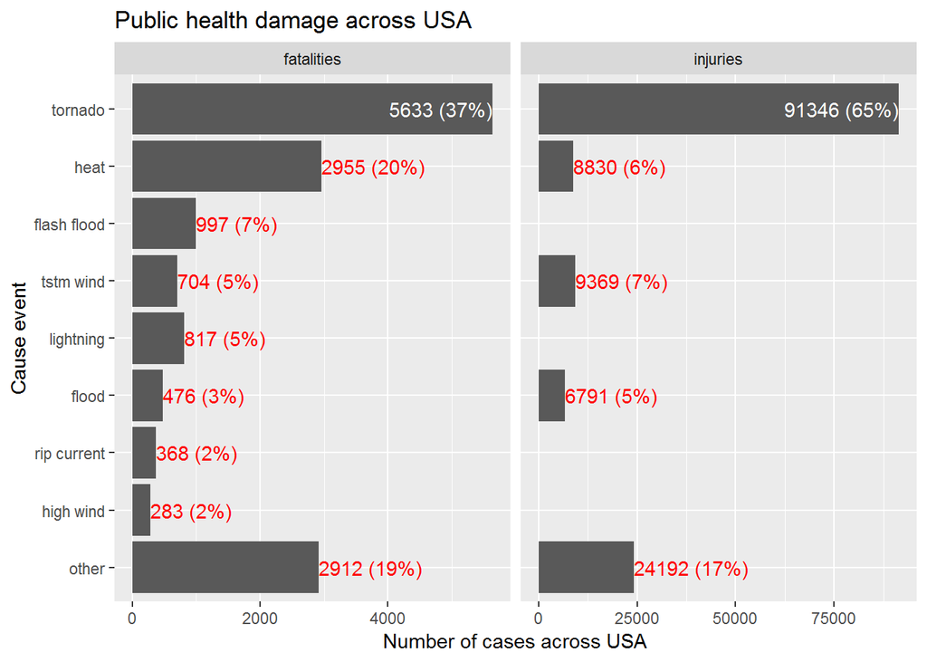

```r
#Health summary
stormHealth=stormSummary[variable %in% c("fatalities","injuries"),
                         .(value=sum(value,na.rm = T),
                           share=sum(share,na.rm = T)),
                         by=.(variable,evtype_health)]
#PC-Damage summary
stormPCDamage=stormSummary[variable %in% c("dmgval"),
                         .(value=sum(value,na.rm = T),
                           share=sum(share,na.rm = T)),
                         by=.(variable,evtype_pcdmg)]


stormHealth[,srt:=ifelse(evtype_health!="other",share,-share)]
stormPCDamage[,srt:=ifelse(evtype_pcdmg!="other",share,-share)]
#setorder(stormSummary,share_fatalities)
ggplot(data=stormHealth,
       aes(x=reorder(evtype_health,srt),y=value)) +
      geom_bar(stat="sum",show.legend = F) + coord_flip() +
      geom_text(data=stormHealth[evtype_health!="tornado"],
                aes(label=sprintf("%s (%s%%)",value,
                                  round(share,2)*100)),
                color="red",hjust="left")+
      geom_text(data=stormHealth[evtype_health=="tornado"],
                aes(label=sprintf("%s (%s%%)",value,
                                  round(share,2)*100)),
                color="white",hjust="right") +
      facet_wrap(.~variable,scales = "free_x") +
      labs(y="Number of cases across USA",x="Cause event")+
      ggtitle("Public health damage across USA")
```

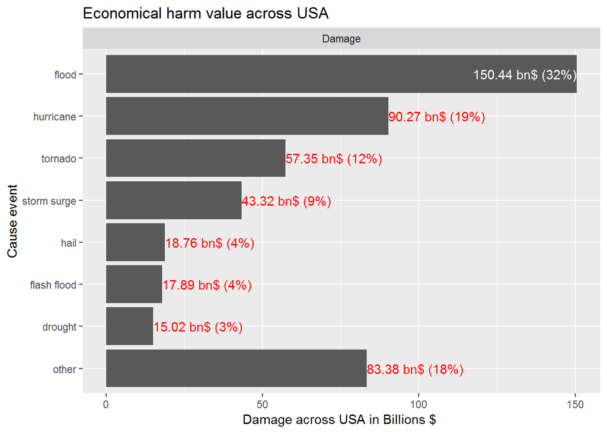

```r
stormPCDamage$variable="Damage"
ggplot(data=stormPCDamage,
       aes(x=reorder(evtype_pcdmg,srt),y=c(value/10^9)))  +
      geom_bar(stat="sum",show.legend = F) + coord_flip() +
            geom_text(data=stormPCDamage[evtype_pcdmg!="flood"],
                aes(label=sprintf("%s bn$ (%s%%)",round(value/10^9,2),
                                  round(share,2)*100)),
                color="red",hjust="left")+
      geom_text(data=stormPCDamage[evtype_pcdmg=="flood"],
                aes(label=sprintf("%s bn$ (%s%%)",round(value/10^9,2),
                                  round(share,2)*100)),
                color="white",hjust="right")+
      facet_wrap(.~variable,scales = "free_x") +
      labs(y="Damage across USA in Billions $ ",x="Cause event") +
      ggtitle("Economical harm value across USA")
```